# R Primer

Krzysztof Mierzejewski

01-04-2018

# 1 Wprowadzenie

- [R: The R Project for Statistical Computing](https://www.r-project.org/)
- Obiektowy język programowania.
- Otwarta implementacja języka S, stworzonego przez Johna Chambersa w [Bell Laboratories](https://en.wikipedia.org/wiki/Bell_Labs) w latach ’70.
- John Chambers należy do [R Dev Core Team](https://developer.r-project.org/).
- Centralne repozytorium pakietów [CRAN](https://cran.r-project.org/).
- Integrated Developer Environment – [RStudio](https://www.rstudio.com/).
- R w przeglądarce: http://www.r-fiddle.org.
- Interaktywne aplikacje webowe w R – [Shiny](https://shiny.rstudio.com/).

## 1.1 Pomoc w R

Podstawowym sposobem na wyszukiwanie informacji (dokumentacji) jest funkcja **help** dostępna także pod synonimem **?**. Argumentem może być funkcja lub jej nazwa, przekazana jako ciąg znakowy.

```r
?help
? 'help'
help(help)
help("help")
```

## 1.2 Komentarze

Komentarze w R są ciągami dowolnych znaków występujących po symbolu **#**, który nie jest elementem ciągu znakowego.

```r
# To jest przykładowy komentarz.
```

## 1.3 Pakiety

Poszczególne funkcjonalności dostarczane do R są grupowane w moduły zwane **pakietami**.

Lista załadowanych pakietów `(.packages())`: caret, ggplot2, lattice, stats, graphics, grDevices, utils, datasets, methods, base.

Lista dostępnych pakietów:

```r
(.packages(all.available=TRUE))
```

Opis zbioru danych:

```r
? cars
```

Załadowanie pakietu:

```r
library(class)
```

*Wyładowanie* pakietu:

```r
detach('package:class', unload=TRUE)
```

Funkcjonalności wszystkich pakietów są zawsze dostępne, dzięki operatorowi zasięgu **::**:

```r
tools::md5sum(dir(
  recursive=T, include.dirs=F)[1])
```

```
                  0.Primer.nb.html
"d4e123364c20f26fee56c610d3a41637"
```

# 2 Syntaktyka języka R

## 2.1 Funkcje

Wywołanie funkcji:

```r
set.seed(123) # ziarno liczby losowej
```

Argumenty pozycyjne:

```r
log(8, 2)
```

```
[1] 3
```

Argumenty nazwane:

```r
log(base=2, x=8)
```

```
[1] 3
```

Argumenty pozycyjne i nazwane:

```r
dir('.', full.names=1, recursive=TRUE)
```

```
[1] "./0.Primer.nb.html"            "./0.Primer.Rmd"                "./1.Linear Regression.nb.html"
[4] "./1.Linear Regression.Rmd"
```

Każde wyrażenie jest funkcją. Jeżeli z przyczyn syntaktycznych nie można użyć symbolu bezpośrednio jako funkcji, należy go zamknąć pomiędzy symbolami *backticks* **`**. Osobne wyrażenia mogą być umieszczone w jednej linii, muszą jednak pozostać oddzielone znakiem średnika **;**:

```r
x<-6:1; `<-`(y, `+`(x, runif(length(x))))
paste(c('x: ', paste(x, collapse=', '), '; y: ', paste(signif(y, 3), collapse=', ')), collapse='')
```

```
[1] "x: 6, 5, 4, 3, 2, 1; y: 6.29, 5.79, 4.41, 3.88, 2.94, 1.05"
```

Każde wyrażenie jest funkcją, cd.:

```r
`==`(-1, FALSE); `^`(2, 3)
```

```
[1] FALSE
[1] 8
```

Funkcja anonimowa:

```r
sapply(x, function(x) 2*x)
```

```
[1] 12 10  8  6  4  2
```

Wartość domyślna argumentu:

```r
g<-function(z, y=10){ return(z+y); }
g(2)
```

```
[1] 12
```

Funkcja jest obiektem, można ją przekazywać:

```r
sapply(x, g)
```

```
[1] 16 15 14 13 12 11
```

Introspekcja:

```r
args(g)
```

```
function (z, y = 10)
NULL
```

Introspekcja argumentów funkcji:

```r
formals(g)
```

```
$z


$y
[1] 10
```

Manipulacja:

```r
formals(g)$y<--1
g(2)
```

```
[1] 1
```

Manipulacja, cd.:

```r
body(g)
```

```
{
    return(z + y)
}
```

```r
body(g) <- expression({z*pi})
g(1)
```

```
[1] 3.141593
```

## 2.2 Zmienne (symbole)

Przypisanie wartości:

```r
d<-4     # przypisanie
d=5      # argument nazwany; globalnie działa jak przypisanie
d.d <- 6 # kropki są dopuszczalnymi elementami nazw zmiennych
```

Typy danych:

```r
-.15; 0x7F; 1.2e3; 1+2i                # liczby
NULL; Inf; NaN; NA; pi; exp(1)         # symbole specjalne
"napis"; 'napis'; "'napis'"; '"napis"' # ciągi znakowe
1==TRUE; 0==FALSE; 2==TRUE; 2==FALSE   # wartości logiczne
1:6; c(1,1,2,3,5,8); seq(1, 2, 0.25)   # wektor wartości homogenicznych
                                       # (.NET / Java / C - tablica, Python ~ lista)
```

Coercion:

```r
c(1, 'dwa', 3)
```

```
[1] "1"   "dwa" "3"
```

Iloczyn skalarny (inner / dot product):

```r
drop(1:3 %*% 3:1)
```

```
[1] 10
```

```r
sum(1:3 * 3:1)
```

```
[1] 10
```

## 2.3 Operatory

```r
1+2; 1-2; 1/2; 2*.5
1:3 * 2; 1:3 - 1
2^3; 2**3; 3%%2; 5%/%2
1==2; 1!=2; 1>2; 1>=2; 1<2; 1<=2
!TRUE; 1 | 0; TRUE || FALSE; TRUE & FALSE; TRUE && FALSE
```

Logical:

```r
c(1,0) && c(1,0)
c(1,0) || c(1,0)
xor(c(1,0,1), c(0,1,1))
```

Elementwise:

```r
c(1,0) & c(1,1)
c(1,0) | c(1,1)
```

## 2.4 Kontrola przepływu

Compound statement - ostatnie wyrażenie jest wartością zwracaną przez wyrażenie:

```r
{'jeden'; 2; 'rezultat'}
```

```
[1] "rezultat"
```

### 2.4.1 if

```r
if (FALSE) NULL else 'nieprawda'
```

```
[1] "nieprawda"
```

### 2.4.2 ifelse

```r
ifelse(sample(rep(0:1, each=3)), 'prawda', 'fałsz')
```

```
[1] "prawda" "prawda" "fałsz"  "fałsz"  "prawda" "fałsz"
```

### 2.4.3 repeat

```r
i<-5; repeat {if (i > 25) break else {print(i); i <- i + 5;}}
```

```
[1] 5
[1] 10
[1] 15
[1] 20
[1] 25
```

### 2.4.4 while

```r
i<-5; while (i <= 25) {print(i); i <- i + 5}
```

```
[1] 5
[1] 10
[1] 15
[1] 20
[1] 25
```

### 2.4.5 for

```r
for (i in seq(from=5, to=25, by=5)) print(i)
```

```
[1] 5
[1] 10
[1] 15
[1] 20
[1] 25
```

# 3 Obiektowość języka R

Atrybuty:

```r
lin.reg<-lm(x~y)
attributes(lin.reg)
```

```
$names
 [1] "coefficients"  "residuals"     "effects"       "rank"          "fitted.values" "assign"
 [7] "qr"            "df.residual"   "xlevels"       "call"          "terms"         "model"

$class
[1] "lm"
```

Atrybuty nazwane:

```r
names(lin.reg)        # to samo co attributes(lin.reg)$names
```

```
 [1] "coefficients"  "residuals"     "effects"       "rank"          "fitted.values" "assign"
 [7] "qr"            "df.residual"   "xlevels"       "call"          "terms"         "model"
```

```r
lin.reg$coefficients  # to samo co coef(lin.reg)
```

```
(Intercept)           y
 -0.3823234   0.9564768
```

Klasa dla funkcji generycznych; w przypadku braku innej możliwości *coercion*:

```r
class(lin.reg)
```

```
[1] "lm"
```

```r
summary(lin.reg)      # to samo co summary.lm(lin.reg)
```

```
Call:
lm(formula = x ~ y)

Residuals:
      1       2       3       4       5       6
 0.3684 -0.1541  0.1652 -0.3317 -0.4302  0.3823

Coefficients:
            Estimate Std. Error t value Pr(>|t|)
(Intercept) -0.38232    0.40793  -0.937 0.401704
y            0.95648    0.09226  10.367 0.000489 ***
---
Signif. codes:  0 ‘***’ 0.001 ‘**’ 0.01 ‘*’ 0.05 ‘.’ 0.1 ‘ ’ 1

Residual standard error: 0.3962 on 4 degrees of freedom
Multiple R-squared:  0.9641,    Adjusted R-squared:  0.9551
F-statistic: 107.5 on 1 and 4 DF,  p-value: 0.0004887
```

```r
methods(class='lm')    # to samo co methods(class=lm)
```

```
 [1] add1           alias          anova          case.names     coerce         confint        cooks.distance
 [8] deviance       dfbeta         dfbetas        drop1          dummy.coef     effects        extractAIC
[15] family         formula        hatvalues      influence      initialize     kappa          labels
[22] logLik         model.frame    model.matrix   nobs           plot           predict        print
[29] proj           qr             residuals      rstandard      rstudent       show           simulate
[36] slotsFromS3    summary        variable.names vcov
see '?methods' for accessing help and source code
```

Typ obiektu R:

```r
typeof(lin.reg)
```

```
[1] "list"
```

Wszystko jest obiektem:

```r
class(typeof)
```

```
[1] "function"
```

```r
typeof(class)
```

```
[1] "builtin"
```

```r
mode(class)
```

```
[1] "function"
```

Konwersja typu:

```r
as.complex(8)
```

```
[1] 8+0i
```

Sprawdzenie typu:

```r
is(0i, 'complex')
```

```
[1] TRUE
```

## 3.1 Indeksowanie

**Indeksowanie kolekcji od 1, nie od 0**:

```r
x[1]; x[[1]]
```

```
[1] 6
[1] 6
```

Wektory liczb mogą być indeksami:

```r
x[1:2]; x[c(2,5,6)]
```

```
[1] 6 5
[1] 5 2 1
```

“*Z wyjątkiem*”:

```r
x[-1:-3]
```

```
[1] 3 2 1
```

```r
m <- matrix(data=c(101:112), nrow=3, ncol=4); print(m)
```

```
     [,1] [,2] [,3] [,4]
[1,]  101  104  107  110
[2,]  102  105  108  111
[3,]  103  106  109  112
```

Wiersz(e), kolumna(y):

```r
m[4]; m[1,2]; m[1:2, 1:2]; m[1,]; m[,2:4]
```

```
[1] 104
[1] 104
     [,1] [,2]
[1,]  101  104
[2,]  102  105
[1] 101 104 107 110
     [,1] [,2] [,3]
[1,]  104  107  110
[2,]  105  108  111
[3,]  106  109  112
```

Wektory wartości logicznych mogą być indeksami:

```r
logical.vector <- sample(6) > 3
x[logical.vector]
```

```
[1] 6 3 2
```

```r
x[x%%2==0]
```

```
[1] 6 4 2
```

```r
list(a=1, b=2, c=3, d=4, e=5, f=6, g=7, h=8, i=9, j=10)[c('a', 'd')]
```

```
$a
[1] 1

$d
[1] 4
```

# 4 Podstawowe typy danych

## 4.1 Listy

Reprezentują wartości heterogeniczne / krotki (*tuple*):

```r
l <- list(1, '2', FALSE, 4, complex=5i)
l[[5]]; l$complex
```

```
[1] 0+5i
[1] 0+5i
```

## 4.2 Macierze

```r
m<-matrix(data=1:12, nrow=4, ncol=3,
          dimnames=list(c('wrsz1', 'wrsz2', 'wrsz3', 'wrsz4'),
                        c('kol1', 'kol2', 'kol3')))
print(m)
```

```
      kol1 kol2 kol3
wrsz1    1    5    9
wrsz2    2    6   10
wrsz3    3    7   11
wrsz4    4    8   12
```

Wymiary macierzy:

```r
dim(m)
```

```
[1] 4 3
```

Nazwy wymiarów macierzy:

```r
dimnames(m)
```

```
[[1]]
[1] "wrsz1" "wrsz2" "wrsz3" "wrsz4"

[[2]]
[1] "kol1" "kol2" "kol3"
```

Nazwy wybranego wymiaru macierzy (tutaj kolumn):

```r
colnames(m)
```

```
[1] "kol1" "kol2" "kol3"
```

Zmiana wartości nazw wymiaru, tutaj wierszy. Należy zwrócić uwagę, że wartości funkcji mogą być *l-value*:

```r
rownames(m) <- NULL
```

Transpozycja macierzy:

```r
m; t(m)
```

```
     kol1 kol2 kol3
[1,]    1    5    9
[2,]    2    6   10
[3,]    3    7   11
[4,]    4    8   12
     [,1] [,2] [,3] [,4]
kol1    1    2    3    4
kol2    5    6    7    8
kol3    9   10   11   12
```

Mnożenie macierzy:

```r
m.2<-3:14
dim(m.2)<-c(dim(m)[2], dim(m)[1])
m; m.2; m.2 %*% m
```

```
     kol1 kol2 kol3
[1,]    1    5    9
[2,]    2    6   10
[3,]    3    7   11
[4,]    4    8   12
     [,1] [,2] [,3] [,4]
[1,]    3    6    9   12
[2,]    4    7   10   13
[3,]    5    8   11   14
     kol1 kol2 kol3
[1,]   90  210  330
[2,]  100  236  372
[3,]  110  262  414
```

## 4.3 Tablice

Trójwymiarowa:

```r
a<-array(data=1:24, dim=c(3, 4, 2))
print(a)
```

```
, , 1

     [,1] [,2] [,3] [,4]
[1,]    1    4    7   10
[2,]    2    5    8   11
[3,]    3    6    9   12

, , 2

     [,1] [,2] [,3] [,4]
[1,]   13   16   19   22
[2,]   14   17   20   23
[3,]   15   18   21   24
```

## 4.4 Factors (*enumeracje*)

```r
traffic.lights<-factor(c('green', 'red', 'red', 'amber', 'green'))
levels(traffic.lights)
```

```
[1] "amber" "green" "red"
```

## 4.5 Data frames (zbiory danych)

```r
data.frame(
  city = c('Seattle', 'Washington', 'Chicago',
           'New York', 'Portland', 'St Louis',
           'Denver', 'Boston','Minneapolis', 'Austin',
           'Philadelphia', 'San Francisco', 'Atlanta',
           'Los Angeles', 'Richardson'), rank = c(100, 96, 94, 93, 93, 92, 90, 90, 89, 87,
                                                    85, 84, 82, 80, 80))
```

| city | rank |
| --- | --- |
| Seattle | 100 |
| Washington | 96 |
| Chicago | 94 |
| New York | 93 |
| Portland | 93 |
| St Louis | 92 |
| Denver | 90 |
| Boston | 90 |
| Minneapolis | 89 |
| Austin | 87 |

[output cut: 5 more lines]

## 4.6 Formuła

```r
summary(y~x)
```

```
 Length   Class    Mode
      3 formula    call
```

## 4.7 Data

```r
Sys.Date()
```

```
[1] "2018-04-03"
```

```r
date()
```

```
[1] "Tue Apr  3 17:42:00 2018"
```

# 5 Dane

## 5.1 Odczyt / Zapis

```r
salary <- c(187000, 165000, 96000, 144000, 158000)
occupation <- c('dev', 'dev', 'test', 'dev', 'dev')
location <- c('WU', 'WE', 'WF', 'WI', 'WN')
name.last <- c('Doe', 'Kowalski', 'Nowak', 'Wski', 'Czyński')
name.first <- c('John', 'Paweł', 'Jan', 'Piotr', 'Zdzisław')
top.5.minions <- data.frame(
  name.last, name.first, location, occupation, salary)
```

```r
View(top.5.minions)  # podgląd
```

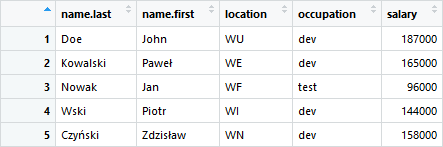

```r
fix(top.5.minions)  # edycja
```

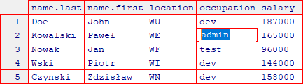

Serializacja binarna – zapis stanu obiektu do zewnętrznego pliku:

```r
save(top.5.minions, file = 'top.5.rdata')
```

Lista aktualnie zadeklarowanych zmiennych:

```r
ls() # to samo co objects()
```

```
  [1] "a"                   "A"                   "alpha"               "autodane"
  [5] "autodata"            "autodata.train"      "aux"                 "aux.numerator"
  [9] "B"                   "B0"                  "B0.conf"             "B0.err"
 [13] "B0.t"                "B0.t.pr"             "B1"                  "B1.conf"
 [17] "B1.err"              "B1.t"                "B1.t.pr"             "B2"
 [21] "B2.conf"             "B2.err"              "B2.t"                "B2.t.pr"
 [25] "c"                   "C"                   "cena"                "cena.diff"
 [29] "cena.diff.power"     "cena.est"            "cena.est.conf"       "cena.est.diff"
 [33] "cena.est.diff.power" "cena.mean"           "coef"                "cov.przebieg.cena"
 [37] "cov.wiek.cena"       "cov.x"               "d"                   "d1"
 [41] "d2"                  "data.test"           "data.train"          "d.d"
 [45] "delta"               "df"                  "doctorates"          "doctorates.m"
 [49] "est.fnc"             "est.var"             "exAnte"              "exAnte.rel"
 [53] "F"                   "ff"                  "F.pValue"            "g"
 [57] "i"                   "indices"             "interval"            "iris"
 [61] "l"                   "lin.reg"             "location"            "logical.vector"
 [65] "m"                   "m.2"                 "minions.no"          "more.cols"
 [69] "n"                   "name.first"          "name.last"           "new.car"
 [73] "next.3.minions"      "nmbrs"               "no"                  "numbers"
 [77] "occupation"          "p"                   "partition"           "przebieg"
 [81] "przebieg.cena.mult"  "przebieg.diff"       "przebieg.diff.power" "przebieg.mean"
 [85] "R2"                  "R2.adj"              "rank"                "reminder3"
 [89] "reminder4"           "result"              "result.conf"         "RSS"
 [93] "S2"                  "salary"              "Sigma"               "top.5.minions"
 [97] "toxins.and.cancer"   "traffic.lights"      "TSS"                 "tValue"
[101] "tValues"             "var.przebieg"        "var.wiek"            "wiek"
[105] "wiek.cena.mult"      "wiek.diff"           "wiek.diff.power"     "wiek.mean"
[109] "x"                   "X"                   "x.1"                 "x.2"
[113] "x.mult"              "y"                   "year"
```

Usuń zmienną:

```r
rm(top.5.minions)
```

Zawartość pliku z serializowanym binarnie obiektem R:

```r
file.show('top.5.rdata')
```

[output not shown]

Deserializacja obiektu z pliku do zmiennej:

```r
load('top.5.rdata')
```

Usunięcie pliku:

```r
file.remove('top.5.rdata')
```

Wczytanie danych z pliku płaskiego:

```r
read.table('/usr/miswdm/autodane.csv', header=1, sep=',')
```

| Cena | Wiek | Przebieg |
| --- | --- | --- |
| 12 | 10 | 180 |
| 22 | 6 | 65 |
| 15 | 8 | 120 |
| 35 | 4 | 50 |
| 21 | 8 | 150 |
| 25 | 7 | 70 |
| 28 | 5 | 100 |
| 33 | 6 | 70 |
| 36 | 3 | 50 |
| 43 | 1 | 15 |

Wczytanie danych z pliku csv (jedna z możliwych kombinacji wartości dostępnych parametrów):

```r
autodane<-read.csv('/usr/miswdm/autodane.csv')
```

Zapis danych do pliku csv (jedna z możliwych kombinacji wartości dostępnych parametrów):

```r
write.csv2(autodane, 'autodane.csv')
```

Wczytanie zbioru danych:

```r
data('iris')
summary(iris)
```

```
  Sepal.Length    Sepal.Width     Petal.Length    Petal.Width          Species
 Min.   :4.300   Min.   :2.000   Min.   :1.000   Min.   :0.100   setosa    :50
 1st Qu.:5.100   1st Qu.:2.800   1st Qu.:1.600   1st Qu.:0.300   versicolor:50
 Median :5.800   Median :3.000   Median :4.350   Median :1.300   virginica :50
 Mean   :5.843   Mean   :3.057   Mean   :3.758   Mean   :1.199
 3rd Qu.:6.400   3rd Qu.:3.300   3rd Qu.:5.100   3rd Qu.:1.800
 Max.   :7.900   Max.   :4.400   Max.   :6.900   Max.   :2.500
```

Pierwsze i ostatnie elementy zbioru:

```r
head(iris)
```

|  | Sepal.Length | Sepal.Width | Petal.Length | Petal.Width | Species |
| --- | --- | --- | --- | --- | --- |
| 1 | 5.1 | 3.5 | 1.4 | 0.2 | setosa |
| 2 | 4.9 | 3.0 | 1.4 | 0.2 | setosa |
| 3 | 4.7 | 3.2 | 1.3 | 0.2 | setosa |
| 4 | 4.6 | 3.1 | 1.5 | 0.2 | setosa |
| 5 | 5.0 | 3.6 | 1.4 | 0.2 | setosa |
| 6 | 5.4 | 3.9 | 1.7 | 0.4 | setosa |

```r
tail(iris, 2)
```

|  | Sepal.Length | Sepal.Width | Petal.Length | Petal.Width | Species |
| --- | --- | --- | --- | --- | --- |
| 149 | 6.2 | 3.4 | 5.4 | 2.3 | virginica |
| 150 | 5.9 | 3.0 | 5.1 | 1.8 | virginica |

Liczba wierszy:

```r
nrow(iris)
```

```
[1] 150
```

Liczba kolumn:

```r
ncol(iris)
```

```
[1] 5
```

## 5.2 Manipulacja

### 5.2.1 Konkatenacja

```r
x.1 <- c('a', 'b', 'c', 'd', 'e')
x.2 <- c('A', 'B', 'C', 'D', 'E')
paste(x.1, x.2)
```

```
[1] "a A" "b B" "c C" "d D" "e E"
```

```r
paste(x.1, x.2, sep=':')
```

```
[1] "a:A" "b:B" "c:C" "d:D" "e:E"
```

```r
paste(x.1, x.2, sep='', collapse='-')
```

```
[1] "aA-bB-cC-dD-eE"
```

Column bind:

```r
minions.no<-length(top.5.minions)
year<-rep(as.integer(format(Sys.Date(), '%Y')),
          minions.no)
rank<-sample(minions.no)
more.cols<-data.frame(year, rank)
cbind(top.5.minions, more.cols)
```

| name.last | name.first | location | occupation | salary | year | rank |
| --- | --- | --- | --- | --- | --- | --- |
| Doe | John | WU | dev | 187000 | 2018 | 2 |
| Kowalski | Paweł | WE | dev | 165000 | 2018 | 4 |
| Nowak | Jan | WF | test | 96000 | 2018 | 3 |
| Wski | Piotr | WI | dev | 144000 | 2018 | 5 |
| Czyński | Zdzisław | WN | dev | 158000 | 2018 | 1 |

Row bind:

```r
next.3.minions<-data.frame(
  name.last=c('Ała', 'Ocha', 'Ska'),
  name.first=c('Wojciech', 'Zbigniew', 'Anna'),
  location=c('WY', 'WX', 'WT'),
  occupation=c('dev', 'tester', 'mgr'),
  salary=c(154000, 75500, 121000),
  year=year[1:3],
  rank=sample(seq(minions.no+1,minions.no+3))
)
rbind(top.5.minions, next.3.minions[-6:-7])
```

| name.last | name.first | location | occupation | salary |
| --- | --- | --- | --- | --- |
| Doe | John | WU | dev | 187000 |
| Kowalski | Paweł | WE | dev | 165000 |
| Nowak | Jan | WF | test | 96000 |
| Wski | Piotr | WI | dev | 144000 |
| Czyński | Zdzisław | WN | dev | 158000 |
| Ała | Wojciech | WY | dev | 154000 |
| Ocha | Zbigniew | WX | tester | 75500 |
| Ska | Anna | WT | mgr | 121000 |

### 5.2.2 Iloczyn kartezjański

```r
numbers<-1:10
nmbrs<-numbers
reminder3=numbers%%3
reminder4=nmbrs%%4
d1<-data.frame(number=numbers, reminder3)
d2<-data.frame(nmbr=nmbrs, reminder4)
merge(d1, d2)
```

| number | reminder3 | nmbr | reminder4 |
| --- | --- | --- | --- |
| 1 | 1 | 1 | 1 |
| 2 | 2 | 1 | 1 |
| 3 | 0 | 1 | 1 |
| 4 | 1 | 1 | 1 |
| 5 | 2 | 1 | 1 |
| 6 | 0 | 1 | 1 |
| 7 | 1 | 1 | 1 |
| 8 | 2 | 1 | 1 |
| 9 | 0 | 1 | 1 |
| 10 | 1 | 1 | 1 |

[output cut: 90 more lines]

Inner join:

```r
merge(d1, d2, by.x='number', by.y='nmbr')
```

| number | reminder3 | reminder4 |
| --- | --- | --- |
| 1 | 1 | 1 |
| 2 | 2 | 2 |
| 3 | 0 | 3 |
| 4 | 1 | 0 |
| 5 | 2 | 1 |
| 6 | 0 | 2 |
| 7 | 1 | 3 |
| 8 | 2 | 0 |
| 9 | 0 | 1 |
| 10 | 1 | 2 |

Natural join:

```r
names(d2)[1]<-'number'
merge(d1, d2)
```

| number | reminder3 | reminder4 |
| --- | --- | --- |
| 1 | 1 | 1 |
| 2 | 2 | 2 |
| 3 | 0 | 3 |
| 4 | 1 | 0 |
| 5 | 2 | 1 |
| 6 | 0 | 2 |
| 7 | 1 | 3 |
| 8 | 2 | 0 |
| 9 | 0 | 1 |
| 10 | 1 | 2 |

Left outer join:

```r
merge(d1, d2[1:nrow(d2)%%2==1,], all.x=1)
```

| number | reminder3 | reminder4 |
| --- | --- | --- |
| 1 | 1 | 1 |
| 2 | 2 | NA |
| 3 | 0 | 3 |
| 4 | 1 | NA |
| 5 | 2 | 1 |
| 6 | 0 | NA |
| 7 | 1 | 3 |
| 8 | 2 | NA |
| 9 | 0 | 1 |
| 10 | 1 | NA |

### 5.2.3 Rodzina funkcji *apply*

Maksimum z wierszy macierzy:

```r
m<-1:20
dim(m)<-c(5,4)
apply(X=m, MARGIN=1, FUN=max)
```

```
[1] 16 17 18 19 20
```

Maksimum z kolumn macierzy

```r
apply(X=m, MARGIN=2, FUN=max)
```

```
[1]  5 10 15 20
```

List apply:

```r
x <- as.list(1:5)
lapply(x,function(x) 2^x)
```

```
[[1]]
[1] 2

[[2]]
[1] 4

[[3]]
[1] 8

[[4]]
[1] 16

[[5]]
[1] 32
```

Stworzenie wektora z wartości listy:

```r
unlist(lapply(x,function(x) 2^x))
```

```
[1]  2  4  8 16 32
```

List apply dla zbioru danych:

```r
d <- data.frame(x=1:5, y=6:10)
lapply(d, FUN=function(x) 2^x)
```

```
$x
[1]  2  4  8 16 32

$y
[1]   64  128  256  512 1024
```

Dla każdego wektora w zbiorze danych:

```r
lapply(d, max)
```

```
$x
[1] 5

$y
[1] 10
```

Apply, który zwraca macierz (ewentualnie wektor albo tablicę):

```r
sapply(d, FUN=function(x) 2^x)
```

```
      x    y
[1,]  2   64
[2,]  4  128
[3,]  8  256
[4,] 16  512
[5,] 32 1024
```

## 5.3 Podzbiory, agregacja

Wyznaczanie wartości funkcji w przedziałach ze względu na zmienną:

```r
autodata<-read.table('/usr/miswdm/Auto.data')
tapply(autodata$mpg, autodata$cylinders, mean)
```

```
       3        4        5        6        8
20.55000 29.28392 27.36667 19.97349 14.96311
```

Wyznaczanie statystyki po danych zagregowanych względem cechy:

```r
aggregate(autodata$mpg,
          by=list(cylinders=autodata$cylinders),
          FUN=mean)
```

| cylinders | x |
| --- | --- |
| 3 | 20.55000 |
| 4 | 29.28392 |
| 5 | 27.36667 |
| 6 | 19.97349 |
| 8 | 14.96311 |

```r
tapply(autodata$acceleration, autodata$cylinders, median)
```

```
   3    4    5    6    8
13.5 16.2 19.9 16.0 13.0
```

Liczba obserwacji dla indeksu całkowitoliczbowego:

```r
tabulate(autodata$year)
```

```
 [1]  0  0  0  0  0  0  0  0  0  0  0  0  0  0  0  0  0  0  0  0  0  0  0  0  0  0  0  0  0  0  0  0  0  0  0  0
[37]  0  0  0  0  0  0  0  0  0  0  0  0  0  0  0  0  0  0  0  0  0  0  0  0  0  0  0  0  0  0  0  0  0 29 27 28
[73] 40 26 30 34 28 36 29 27 28 30
```

Liczba obserwacji dla wskaźnika:

```r
table(autodata$year)
```

```
70 71 72 73 74 75 76 77 78 79 80 81 82
29 27 28 40 26 30 34 28 36 29 27 28 30
```

Podzbiór:

```r
subset(autodata, select = c(name, year, acceleration),
       subset = horsepower >= median(autodata$horsepower))
```

|  | name | year | acceleration |
| --- | --- | --- | --- |
| 1 | chevrolet chevelle malibu | 70 | 12.0 |
| 2 | buick skylark 320 | 70 | 11.5 |
| 3 | plymouth satellite | 70 | 11.0 |
| 4 | amc rebel sst | 70 | 12.0 |
| 5 | ford torino | 70 | 10.5 |
| 6 | ford galaxie 500 | 70 | 10.0 |
| 7 | chevrolet impala | 70 | 9.0 |
| 8 | plymouth fury iii | 70 | 8.5 |
| 9 | pontiac catalina | 70 | 10.0 |
| 10 | amc ambassador dpl | 70 | 8.5 |

[output cut: 186 more lines]

Dyskretyzacja ciągłej zmiennej przedziałami:

```r
c<-cut(rnorm(40, mean = 60, sd = 10), breaks = 4)
c
```

```
 [1] (61,71.4]   (50.7,61]   (71.4,81.7] (61,71.4]   (40.3,50.7] (61,71.4]   (50.7,61]   (40.3,50.7] (50.7,61]
[10] (40.3,50.7] (50.7,61]   (50.7,61]   (40.3,50.7] (61,71.4]   (61,71.4]   (40.3,50.7] (71.4,81.7] (61,71.4]
[19] (50.7,61]   (61,71.4]   (61,71.4]   (61,71.4]   (61,71.4]   (61,71.4]   (50.7,61]   (50.7,61]   (50.7,61]
[28] (50.7,61]   (50.7,61]   (40.3,50.7] (71.4,81.7] (71.4,81.7] (40.3,50.7] (50.7,61]   (50.7,61]   (61,71.4]
[37] (50.7,61]   (61,71.4]   (50.7,61]   (50.7,61]
Levels: (40.3,50.7] (50.7,61] (61,71.4] (71.4,81.7]
```

```r
table(c)
```

```
c
(40.3,50.7]   (50.7,61]   (61,71.4] (71.4,81.7]
          7          16          13           4
```

# 6 Operacje na zbiorach

Podział na zbiór uczący i walidujący przez próbkowanie losowe:

```r
autodata.train<-rep(FALSE, nrow(autodata))
autodata.train[sample(1:nrow(autodata), 0.75*nrow(autodata))]<-TRUE
data.train<-autodata[autodata.train, c(-3, -8)]
data.test<-autodata[!autodata.train, c(-3, -8)]
nrow(data.test) + nrow(data.train) == nrow(autodata)
```

```
[1] TRUE
```

```r
suppressMessages(library(caret))
partition<-createDataPartition(iris$Species, p=.75, list=FALSE)
data.train<-iris[partition,]
data.test<-iris[-partition,]
nrow(data.test) + nrow(data.train) == nrow(iris)
```

```
[1] TRUE
```

Usuwanie duplikatów:

```r
autodata[!duplicated(autodata$name),]
```

|  | mpg | cylinders | displacement | horsepower | weight | acceleration | year | origin | name |
| --- | --- | --- | --- | --- | --- | --- | --- | --- | --- |
| 1 | 18.0 | 8 | 307.0 | 130 | 3504 | 12.0 | 70 | 1 | chevrolet chevelle malibu |
| 2 | 15.0 | 8 | 350.0 | 165 | 3693 | 11.5 | 70 | 1 | buick skylark 320 |
| 3 | 18.0 | 8 | 318.0 | 150 | 3436 | 11.0 | 70 | 1 | plymouth satellite |
| 4 | 16.0 | 8 | 304.0 | 150 | 3433 | 12.0 | 70 | 1 | amc rebel sst |
| 5 | 17.0 | 8 | 302.0 | 140 | 3449 | 10.5 | 70 | 1 | ford torino |
| 6 | 15.0 | 8 | 429.0 | 198 | 4341 | 10.0 | 70 | 1 | ford galaxie 500 |
| 7 | 14.0 | 8 | 454.0 | 220 | 4354 | 9.0 | 70 | 1 | chevrolet impala |
| 8 | 14.0 | 8 | 440.0 | 215 | 4312 | 8.5 | 70 | 1 | plymouth fury iii |
| 9 | 14.0 | 8 | 455.0 | 225 | 4425 | 10.0 | 70 | 1 | pontiac catalina |
| 10 | 15.0 | 8 | 390.0 | 190 | 3850 | 8.5 | 70 | 1 | amc ambassador dpl |

[output cut: 291 more lines]

Ranking kolejności elementów:

```r
x<-sample(1:10, 4)
order(x)
```

```
[1] 4 1 2 3
```

Sortowanie wektora:

```r
sort(x, decreasing = FALSE)
```

```
[1] 1 2 5 7
```

# 7 Wizualizacja

## 7.1 Plot

Funkcje `plot`, `abline` oraz `grid`:

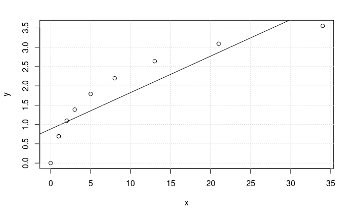

```r
x<-c(0,1,1,2,3,5,8,13,21,34)
y<-log(x+1)
m<-lm(y ~ x)
plot(y ~ x); abline(m); grid()
```

Współrzędne wskazania kursorem:

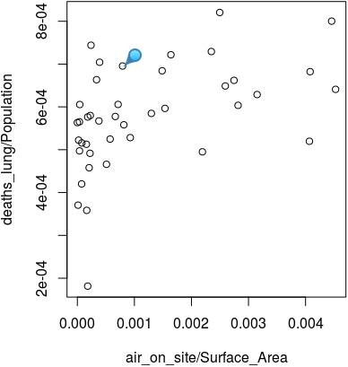

```
$x
[1] 0.0003928701

$y
[1] 0.0007044395
```

```r
toxins.and.cancer=read.csv('/usr/miswdm/toxins.and.cancer.csv')
attach(toxins.and.cancer)                                       # globalna dostępność data frame'u
plot(air_on_site/Surface_Area, deaths_lung/Population)
locator(1)
```

Dodatkowe etykiety wskazanych punktów:

```r
identify(air_on_site/Surface_Area,
         deaths_lung/Population, State_Abbrev)
```

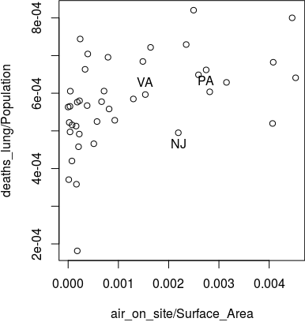

## 7.2 Barplot

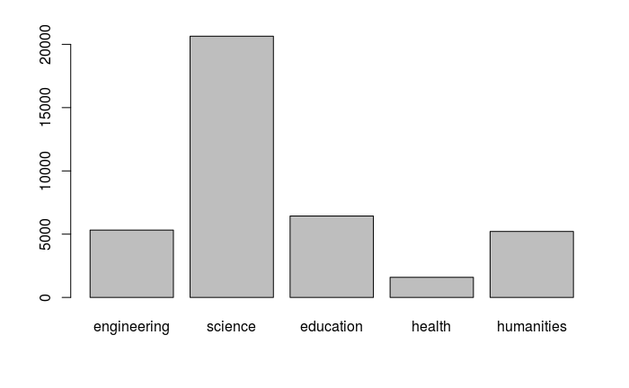

```r
doctorates<-read.csv('/usr/miswdm/doctorates.csv')
doctorates.m <- as.matrix(doctorates[3:7])              # lista jako macierz, wymóg barplot
rownames(doctorates.m) <- doctorates[, 2]
barplot(doctorates.m[1, ])                              # w 2001 roku
```

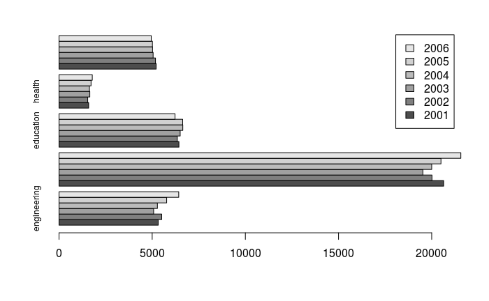

```r
barplot(doctorates.m, beside=TRUE, horiz=TRUE,
        legend=TRUE, cex.names=.75)
```

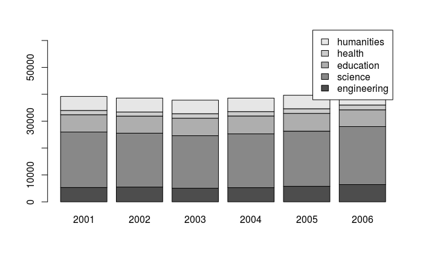

```r
barplot(t(doctorates.m), legend=TRUE, ylim=c(0, 66000))
```

## 7.3 Histogram

Histogram rozkładu normalnego:

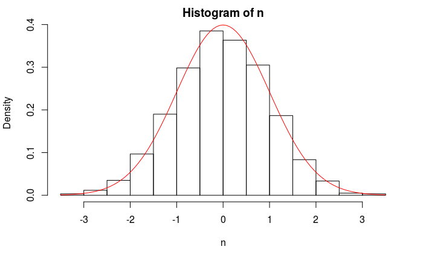

```r
n<-rnorm(1200)
hist(n, breaks = 11, prob=T)
curve(dnorm(x), col=2, add=T)  # funkcja gęstości prawdopodobieństwa rozkładu normalnego
```

## 7.4 Krzywa

Funkcja *curve*:

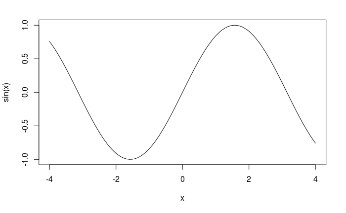

```r
curve(sin, -4, 4)
```

# 8 Wybrane funkcje statystyczne

*Rysowanie* rozkładu:

```r
stem(n)
```

```
  The decimal point is at the |

  -3 | 00
  -2 | 77666655
  -2 | 444333332222211111100000000
  -1 | 9999999998888888777777777777777766666666666655555555555555555
  -1 | 44444444444444444433333333333333333333222222222222222222221111111111+42
  -0 | 99999999999999999999999999999988888888888888888888888888888888777777+107
  -0 | 44444444444444444444444444444443333333333333333333333333333333333333+125
   0 | 00000000000000000011111111111111111111111111111111111111111111111111+128
   0 | 55555555555555555555555566666666666666666666666666666666666666666666+100
   1 | 00000000000000000000000000000000111111111111111111111111111111122222+39
   1 | 5555555555555555566666666666666777777777777888888899999
   2 | 00112233333333334444
   2 | 5677
   3 | 13
```

Maksimum:

```r
max(n)
```

```
[1] 3.30433
```

Minimum:

```r
min(n)
```

```
[1] -3.046967
```

Średnia:

```r
mean(n)
```

```
[1] -0.02948162
```

Odchylenie standardowe:

```r
sd(n)
```

```
[1] 1.002142
```

Wariancja; zgodny, nieobciążony estymator dla próbki:  
$\begin{aligned} Var(X)=\frac{1}{n-1}\sum_{i=1}^{n}(x_i-\bar{x})^2 \end{aligned}$

```r
var(n)
```

```
[1] 1.004288
```

Mediana:

```r
median(n)
```

```
[1] -0.02470827
```

Kwantyle rozkładu:

```r
quantile(n, probs=c(0, .4, .5, .6, 1))
```

```
         0%         40%         50%         60%        100%
-3.04696657 -0.27647091 -0.02470827  0.22162236  3.30432984
```

*Tukey’s summary*:

```r
fivenum(n)
```

```
[1] -3.04696657 -0.69400946 -0.02470827  0.66303614  3.30432984
```

Podsumowanie rozkładu i jego wybranych statystyk:

```r
summary(n)
```

```
    Min.  1st Qu.   Median     Mean  3rd Qu.     Max.
-3.04697 -0.69337 -0.02471 -0.02948  0.66293  3.30433
```

Współczynnik korelacji Pearsona:

```r
cor (x, y)
```

```
[1] 0.9068053
```

Współczynnik korelacji Spearmana:

```r
cor (x, y, method="spearman")
```

```
[1] 1
```

Współczynnik kowariancji zmiennych losowych $Cov(X, Y)=\mathbb{E}[(X-\mathbb{E}[X])\cdot(Y-\mathbb{E}[Y])]=\mathbb{E}[XY]-\mathbb{E}[X]\cdot\mathbb{E}[Y]$:

```r
cov (x, y)
```

```
[1] 11.49988
```

Współczynnik kowariancji zmiennej losowej z samą sobą $Cov(X, X)=\mathbb{E}[(X-\mathbb{E}[X])^2]=\mathbb{E}[X^2]-{\mathbb{E}[X]}^2=Var(X)$:

```r
cov(x, x) == var(x)
```

```
[1] TRUE
```

# 9 Koniec sesji

```r
q()
```